# The Explanandum

Julia Rohrer

2024-12-09

## What is the observation that we seek to explain?

The official Youth Survey report 2023 reports that in 2023, girls have become less satisfied with their lives than they used to be in 2015 – more so than boys. Let’s look at that pattern and also take into account the 2010 data.

### Regression analysis

We can conduct a simple regression analysis to see whether life satisfaction really decreases for for girls in particular.

```r
simple_model <- lm(scale(satis) ~ as.factor(year)*as.factor(gender), data = combined, weights = wph)
summary(simple_model)
```

```
##
## Call:
## lm(formula = scale(satis) ~ as.factor(year) * as.factor(gender),
##     data = combined, weights = wph)
##
## Weighted Residuals:
##     Min      1Q  Median      3Q     Max
## -4.0944 -0.5437  0.1056  0.5962  2.2307
##
## Coefficients:
##                                           Estimate Std. Error t value Pr(>|t|)
## (Intercept)                               -0.01008    0.03610  -0.279    0.780
## as.factor(year)2015                       -0.04895    0.04887  -1.002    0.317
## as.factor(year)2023                       -0.41462    0.04784  -8.666  < 2e-16
## as.factor(gender)male                      0.25671    0.05151   4.984 6.46e-07
## as.factor(year)2015:as.factor(gender)male  0.07782    0.07099   1.096    0.273
## as.factor(year)2023:as.factor(gender)male  0.29961    0.06801   4.405 1.08e-05
##
## (Intercept)
## as.factor(year)2015
## as.factor(year)2023                       ***
## as.factor(gender)male                     ***
## as.factor(year)2015:as.factor(gender)male
## as.factor(year)2023:as.factor(gender)male ***
## ---
## Signif. codes:  0 '***' 0.001 '**' 0.01 '*' 0.05 '.' 0.1 ' ' 1
##
## Residual standard error: 0.9693 on 4836 degrees of freedom
##   (120 observations deleted due to missingness)
## Multiple R-squared:  0.05969,    Adjusted R-squared:  0.05872
## F-statistic:  61.4 on 5 and 4836 DF,  p-value: < 2.2e-16
```

#### Results of a simple regression model

Upon first glance, these numbers fit the reported pattern. Notice that the reference group here is girls in 2010. In 2010, boys were already happier than girls by 0.26 SD. In 2023, girls’ life satisfaction decreased noticeably: -0.41 SD. And there is a significant interaction of 0.3 SD indicating that boys decreased less. If we add up the corresponding numbers, we see that boys only decreased by -0.41 SD + 0.3 SD = -0.11 SD, which is significantly different from the decrease in girls (that’s what the significant interaction term tells us). We can also put this another way: In 2023, the gap between girls and boys grew from 0.26 SD to 0.56 SD and the difference between those gaps is significant (that’s what the significant interaction term tells us).

In contrast, not much seems to be going on between 2010 and 2015.

This way to look at the results is rather tedious, so let’s generate some plots to look at the actual means.

### Generate plots

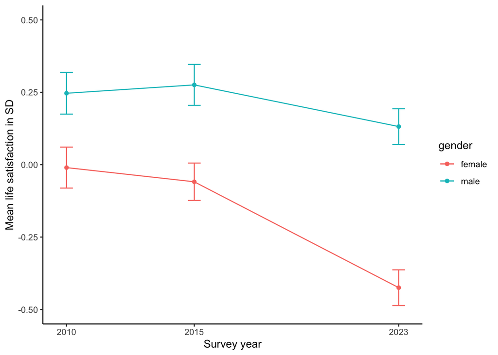

```r
library(marginaleffects)
library(ggplot2)
# generate predictions for combinations of gender and year
pred <- predictions(simple_model,
                 by = c("gender", "year"))

ggplot(pred, aes(x = year, group = gender, color = gender, y = estimate, ymin = conf.low, ymax = conf.high)) +
  geom_point() +
  geom_line() +
  geom_errorbar(width = .5) +
  scale_x_continuous(breaks = c(2010, 2015, 2023)) +
  coord_cartesian(ylim = c(-0.5, 0.5)) +
  theme_classic() +
  ylab("Mean life satisfaction in SD") +
  xlab("Survey year")
```

## A brief preview of what’s going to come

In the following, we will walk through a number of explanations for this pattern. These range from “artifactual” explanations (maybe something is wrong with our data or analysis which can explain the pattern) to substantive explanations (maybe we can pin down what changed for girls but did not change for girls).

“Artifactual” explanations that we will consider:

- maybe the changes in sampling scheme caused the drop, without any real changes in the population – for example, maybe somehow in 2023 parts of Leipzig with more unhappy girls were sampled; maybe the age in the sample changed
- maybe changes in survey mode can explain the differences
- maybe the composition of the underlying population changed – for example, maybe an influx of unhappy girls with migration background can explain the pattern
- maybe this is a scaling artifact – maybe the drop in latent happiness in girls is actually comparable to the drop in latent happiness in boys

But before we dive into that, let’s actually look how the other satisfaction items changed over time, for boys and for girls. While these patterns may also be considered part of the explanadum, they may also give specific hints to potential substantive explanations.

## But let’s look at the other satisfaction items first

### Financial situation

The same question was asked in all three years: How satisfied are you with the money you have to get by with?

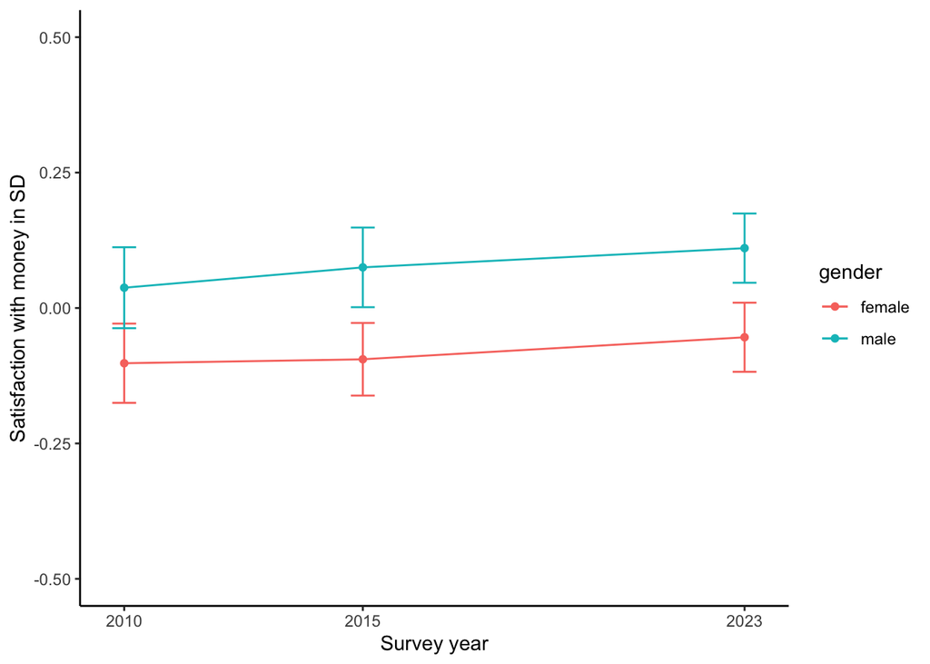

```r
simple_money <- lm(scale(satis_money) ~ as.factor(year)*as.factor(gender), data = combined, weights = wph)
# generate predictions for combinations of gender and year
pred_money <- predictions(simple_money,
                 by = c("gender", "year"))

ggplot(pred_money, aes(x = year, group = gender, color = gender, y = estimate, ymin = conf.low, ymax = conf.high)) +
  geom_point() +
  geom_line() +
  geom_errorbar(width = .5) +
  scale_x_continuous(breaks = c(2010, 2015, 2023)) +
  coord_cartesian(ylim = c(-0.5, 0.5)) +
  theme_classic() +
  ylab("Satisfaction with money in SD") +
  xlab("Survey year")
```

### Relationships with friends

The same question was asked in all three years: How satisfied are you with your relationships to friends?

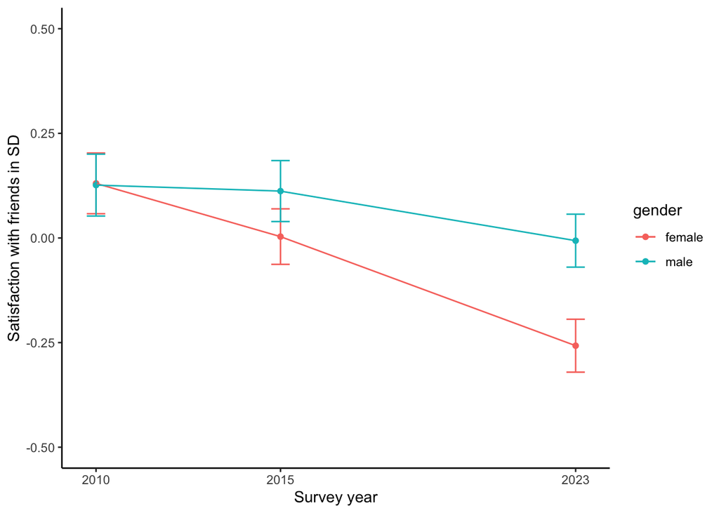

```r
simple_friends <- lm(scale(satis_friends) ~ as.factor(year)*as.factor(gender), data = combined, weights = wph)
# generate predictions for combinations of gender and year
pred_friends <- predictions(simple_friends,
                 by = c("gender", "year"))

ggplot(pred_friends, aes(x = year, group = gender, color = gender, y = estimate, ymin = conf.low, ymax = conf.high)) +
  geom_point() +
  geom_line() +
  geom_errorbar(width = .5) +
  scale_x_continuous(breaks = c(2010, 2015, 2023)) +
  coord_cartesian(ylim = c(-0.5, 0.5)) +
  theme_classic() +
  ylab("Satisfaction with friends in SD") +
  xlab("Survey year")
```

### Relationship with mother

The same question was asked in all three years: How satisfied are you with your relationship to your mom?

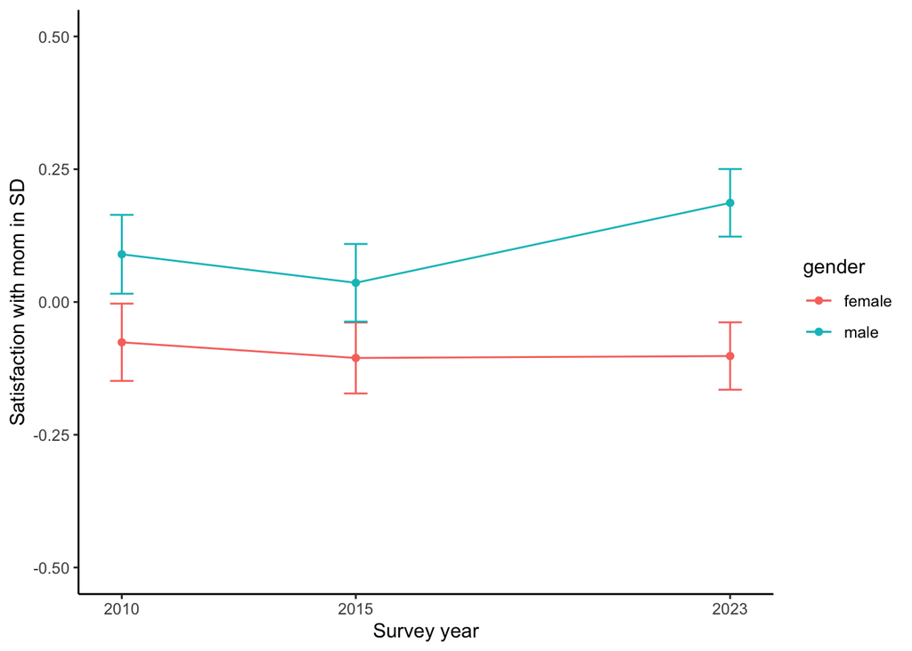

```r
simple_mom <- lm(scale(satis_mom) ~ as.factor(year)*as.factor(gender), data = combined, weights = wph)
# generate predictions for combinations of gender and year
pred_mom <- predictions(simple_mom,
                 by = c("gender", "year"))

ggplot(pred_mom, aes(x = year, group = gender, color = gender, y = estimate, ymin = conf.low, ymax = conf.high)) +
  geom_point() +
  geom_line() +
  geom_errorbar(width = .5) +
  scale_x_continuous(breaks = c(2010, 2015, 2023)) +
  coord_cartesian(ylim = c(-0.5, 0.5)) +
  theme_classic() +
  ylab("Satisfaction with mom in SD") +
  xlab("Survey year")
```

### Relationship with father

The same question was asked in all three years: How satisfied are you with your relationship to your dad?

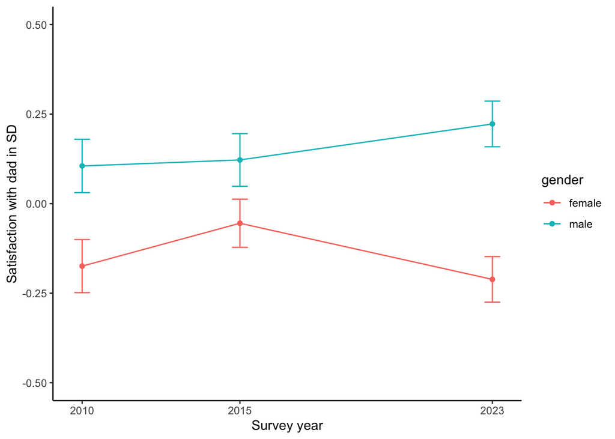

```r
simple_dad <- lm(scale(satis_dad) ~ as.factor(year)*as.factor(gender), data = combined, weights = wph)
# generate predictions for combinations of gender and year
pred_dad <- predictions(simple_dad,
                 by = c("gender", "year"))

ggplot(pred_dad, aes(x = year, group = gender, color = gender, y = estimate, ymin = conf.low, ymax = conf.high)) +
  geom_point() +
  geom_line() +
  geom_errorbar(width = .5) +
  scale_x_continuous(breaks = c(2010, 2015, 2023)) +
  coord_cartesian(ylim = c(-0.5, 0.5)) +
  theme_classic() +
  ylab("Satisfaction with dad in SD") +
  xlab("Survey year")
```

### Leisure

Here, different questions were asked over the years.

2010 and 2015: How satisfied are you with possibilities for leisure time activities?

2023: How satisfied are you with your leisure time activities?

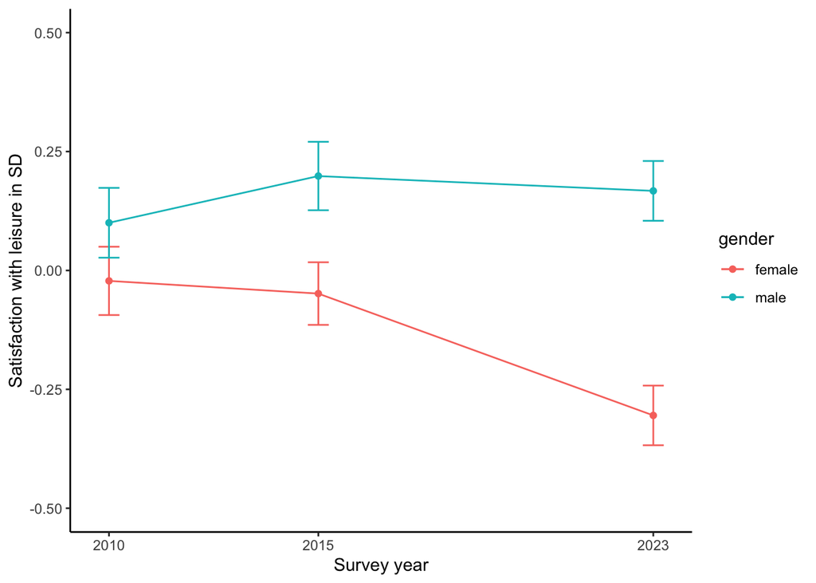

```r
simple_leisure <- lm(scale(satis_leisure) ~ as.factor(year)*as.factor(gender), data = combined, weights = wph)
# generate predictions for combinations of gender and year
pred_leisure <- predictions(simple_leisure,
                 by = c("gender", "year"))

ggplot(pred_leisure, aes(x = year, group = gender, color = gender, y = estimate, ymin = conf.low, ymax = conf.high)) +
  geom_point() +
  geom_line() +
  geom_errorbar(width = .5) +
  scale_x_continuous(breaks = c(2010, 2015, 2023)) +
  coord_cartesian(ylim = c(-0.5, 0.5)) +
  theme_classic() +
  ylab("Satisfaction with leisure in SD") +
  xlab("Survey year")
```

### Dwelling

The same question was asked in all three years: How satisfied are you with your housing situation?

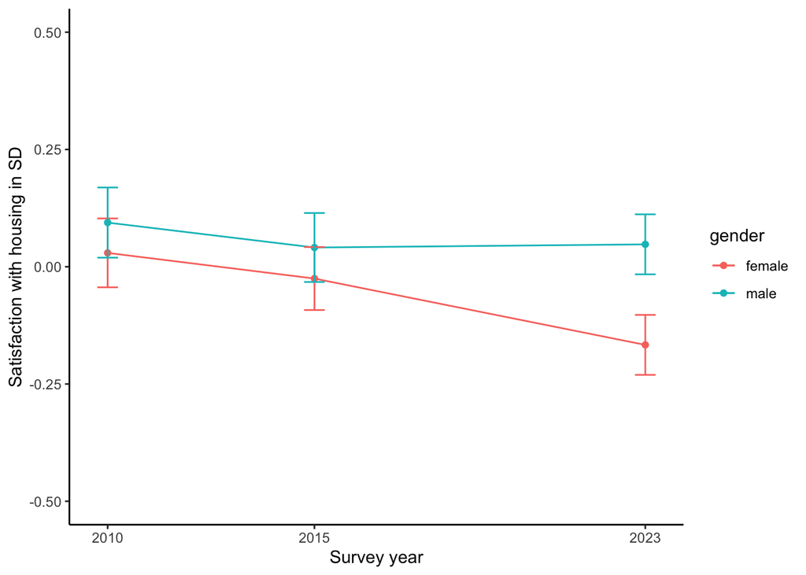

```r
simple_dwell <- lm(scale(satis_dwell) ~ as.factor(year)*as.factor(gender), data = combined, weights = wph)
# generate predictions for combinations of gender and year
pred_dwell <- predictions(simple_dwell,
                 by = c("gender", "year"))

ggplot(pred_dwell, aes(x = year, group = gender, color = gender, y = estimate, ymin = conf.low, ymax = conf.high)) +
  geom_point() +
  geom_line() +
  geom_errorbar(width = .5) +
  scale_x_continuous(breaks = c(2010, 2015, 2023)) +
  coord_cartesian(ylim = c(-0.5, 0.5)) +
  theme_classic() +
  ylab("Satisfaction with housing in SD") +
  xlab("Survey year")
```

### Grades

Here, slightly different phrasings were used over the years:

2010 and 2015: How satisfied are you with your school grades [German: Zensuren]?

2023: How satisfied are you with your school grades [German: Schulnoten]?

The word used in 2010 and 2015 is considerably more formal/old fashioned than the word used in 2023.

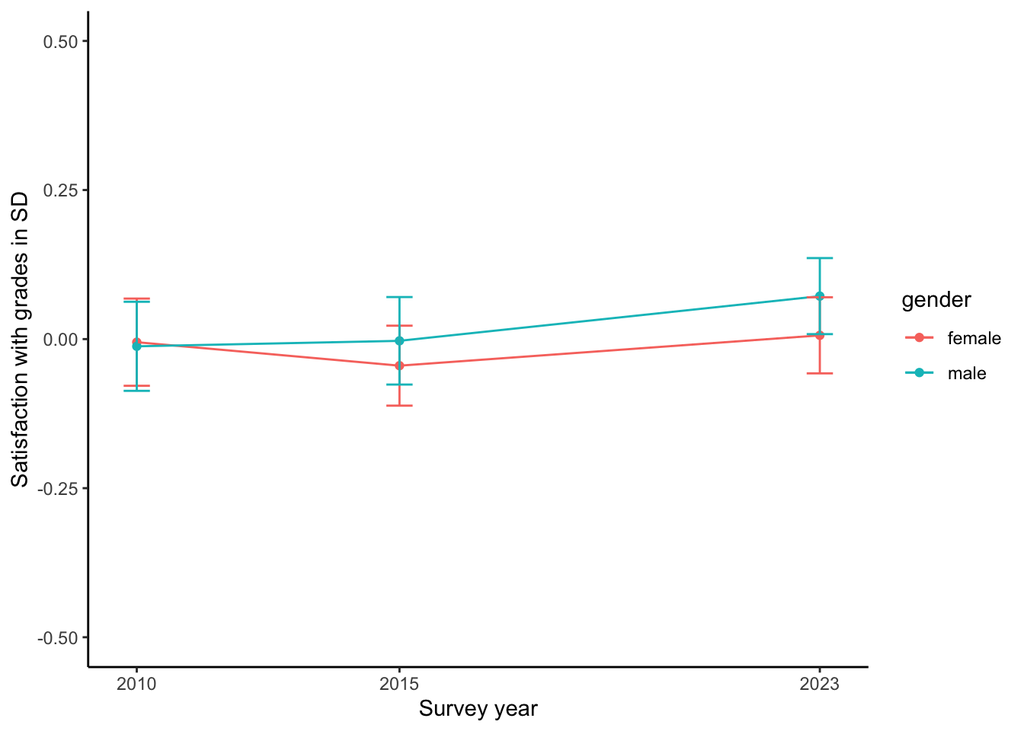

```r
simple_grades <- lm(scale(satis_grades) ~ as.factor(year)*as.factor(gender), data = combined, weights = wph)
# generate predictions for combinations of gender and year
pred_grades <- predictions(simple_grades,
                 by = c("gender", "year"))

ggplot(pred_grades, aes(x = year, group = gender, color = gender, y = estimate, ymin = conf.low, ymax = conf.high)) +
  geom_point() +
  geom_line() +
  geom_errorbar(width = .5) +
  scale_x_continuous(breaks = c(2010, 2015, 2023)) +
  coord_cartesian(ylim = c(-0.5, 0.5)) +
  theme_classic() +
  ylab("Satisfaction with grades in SD") +
  xlab("Survey year")
```